# DSA 8020 R Lab 1: Simple Linear Regression

Whitney

January 25, 2025

# Leaning Tower of Pisa

The dataset provides annual measurements of the lean (the difference between where a point on the tower would be if the tower were straight and where it actually is) from 1975 to 1987. We would like to characterize lean over time by fitting a simple linear regression.

## Load the dataset

**Code:**

```r
getwd()
```

```
## [1] "C:/Users/sar-home/Clemson/Spring_2025_Semester_2/DSA-8020/R_Labs"
```

```r
PisaTower <- read.csv("datasets/PisaTower.csv")
head(PisaTower)
```

|  | lean | year |
| --- | --- | --- |
| 1 | 2.9642 | 1975 |
| 2 | 2.9644 | 1976 |
| 3 | 2.9656 | 1977 |
| 4 | 2.9667 | 1978 |
| 5 | 2.9673 | 1979 |
| 6 | 2.9688 | 1980 |

## Descriptive analysis

### Numerical summary

Provide some numerical summaries to describe the response and the predictor variables, respectively, as well as their relationship.

**Code:**

```r
str(PisaTower)
```

```
## 'data.frame':    13 obs. of  2 variables:
##  $ lean: num  2.96 2.96 2.97 2.97 2.97 ...
##  $ year: int  1975 1976 1977 1978 1979 1980 1981 1982 1983 1984 ...
```

```r
summary(PisaTower$lean)
```

```
##    Min. 1st Qu.  Median    Mean 3rd Qu.    Max.
##   2.964   2.967   2.970   2.969   2.972   2.976
```

```r
summary(PisaTower$year)
```

```
##    Min. 1st Qu.  Median    Mean 3rd Qu.    Max.
##    1975    1978    1981    1981    1984    1987
```

```r
summary_lean <- PisaTower %>%
  summarise(
    mean_lean = mean(lean, na.rm = TRUE),
    median_lean = median(lean, na.rm = TRUE),
    sd_lean = sd(lean, na.rm = TRUE),
    min_lean = min(lean, na.rm = TRUE),
    max_lean = max(lean, na.rm = TRUE)
  )

summary_lean
```

| mean_lean | median_lean | sd_lean | min_lean | max_lean |
| --- | --- | --- | --- | --- |
| 2.969369 | 2.9696 | 0.003651115 | 2.9642 | 2.9757 |

```r
summary_year <- PisaTower %>%
  summarise(
    mean_year = mean(year, na.rm = TRUE),
    median_year = median(year, na.rm = TRUE),
    sd_year = sd(year, na.rm = TRUE),
    min_year = min(year, na.rm = TRUE),
    max_year = max(year, na.rm = TRUE)
  )

summary_year
```

| mean_year | median_year | sd_year | min_year | max_year |
| --- | --- | --- | --- | --- |
| 1981 | 1981 | 3.89444 | 1975 | 1987 |

### Graphical summary

Provide graphical summaries through plots to describe the response and predictor variables, respectively, as well as their relationship.

**Code:**

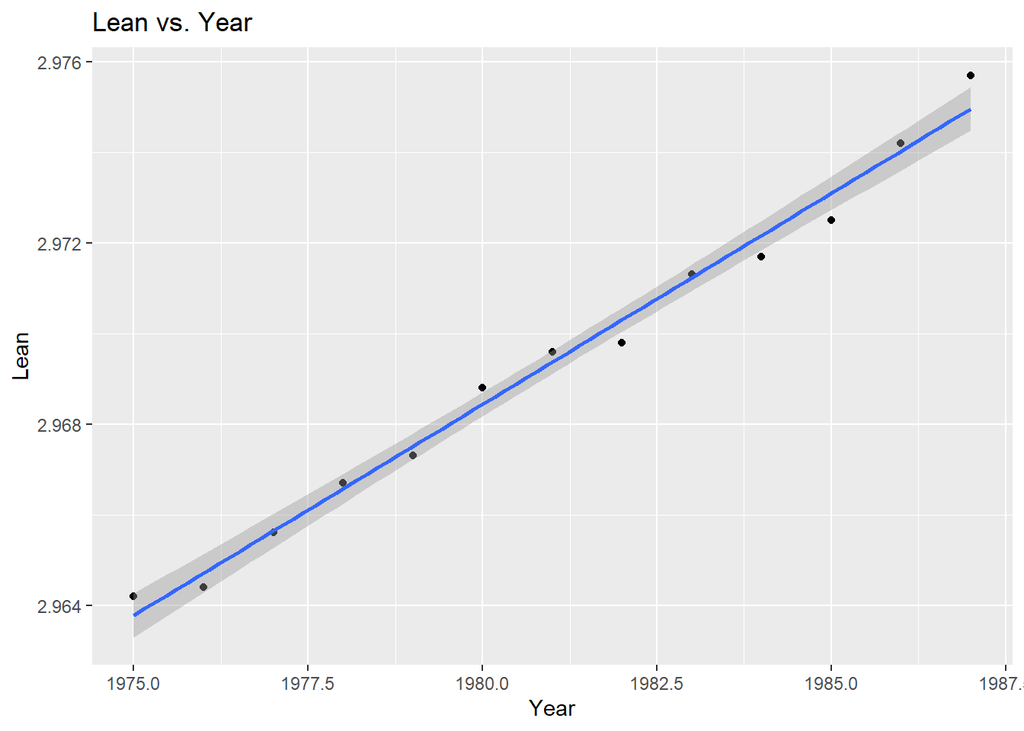

```r
ggplot(PisaTower, aes(x = year, y = lean)) +
  geom_point() +
  geom_smooth(method = "lm") +
  labs(title = "Lean vs. Year", x = "Year", y = "Lean")
```

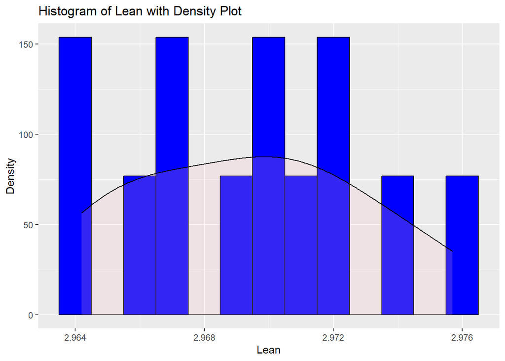

```r
ggplot(PisaTower, aes(x = lean)) +
  geom_histogram(aes(y = ..density..), binwidth = 0.001, fill = "blue", color = "black") +
  geom_density(alpha = .2, fill = "pink") + # Adding some transparency to the density plot for better visibility
  labs(title = "Histogram of Lean with Density Plot", x = "Lean", y = "Density")
```

**Question:** Describe the direction, strength, and the form of the relationship.

**Answer:**

For our scatter plot:

> The graph indicates that generally the lean values are increasing with time (year). The data points’ general upward trajectory when plotted against time suggests a positive trend. The relationship heading has a positive feel to it, as there is one overall increase that exists in lean and year. If the points are close together with a little scatter, the relationship is strong, as we can see from the spread of the data points. On the other hand, points that are scattered or spread out suggest a less strong relationship. The level of correlation is not something we can quantify precisely without various statistical measures like the correlation coefficient. The linear regression line drawn through the data points shows that the form of relationship is likely linear. A straight line or smooth curve would suggest that the lean increases steadily through time.

## Simple linear regression

1. Identify the response variable, the predictor variable, and the sample size.

**Answer:**

Response Variable: - Lean

Predictor Variable: - Year

Sample Size: - n = 13

2. Fit a simple linear regression.

**Code:**

```r
PisaTower <- read.csv("datasets/PisaTower.csv")
head(PisaTower)
```

|  | lean | year |
| --- | --- | --- |
| 1 | 2.9642 | 1975 |
| 2 | 2.9644 | 1976 |
| 3 | 2.9656 | 1977 |
| 4 | 2.9667 | 1978 |
| 5 | 2.9673 | 1979 |
| 6 | 2.9688 | 1980 |

```r
nrow(PisaTower)
```

```
## [1] 13
```

```r
lm <- lm(lean ~ year, data = PisaTower)
summary(lm)
```

```
##
## Call:
## lm(formula = lean ~ year, data = PisaTower)
##
## Residuals:
##        Min         1Q     Median         3Q        Max
## -5.967e-04 -3.099e-04  6.703e-05  2.308e-04  7.396e-04
##
## Coefficients:
##              Estimate Std. Error t value Pr(>|t|)
## (Intercept) 1.123e+00  6.139e-02   18.30 1.39e-09 ***
## year        9.319e-04  3.099e-05   30.07 6.50e-12 ***
## ---
## Signif. codes:  0 '***' 0.001 '**' 0.01 '*' 0.05 '.' 0.1 ' ' 1
##
## Residual standard error: 0.0004181 on 11 degrees of freedom
## Multiple R-squared:  0.988,  Adjusted R-squared:  0.9869
## F-statistic: 904.1 on 1 and 11 DF,  p-value: 6.503e-12
```

3. Write down the fitted linear regression model.

**Answer:**

$\hat{lean}$ = 1.123 + 0.0009319 * year

4. What is $\hat{\sigma}$, the estimate of $\sigma$?

**Answer:**

$\hat{\sigma}$ = 0.0004181 where $\hat{\sigma}$ is Residual standard error.

5. Find a 95% confidence interval for $\beta_{1}$.

**Code:**

```r
confint(lm, level = 0.95)
```

```
##                    2.5 %     97.5 %
## (Intercept) 0.9882109317 1.25846599
## year        0.0008636565 0.00100008
```

```r
beta1_hat <- lm$coefficients[2]  # slope estimate
se_beta1_hat <- summary(lm)[["coefficients"]][2, 2] # standard error

n <- nrow(PisaTower) # count observations
alpha <- 0.05 # significance for .95 confidence interval

t <- qt(1 - alpha / 2, n - 2)

# Confidence Interval
beta1_ci <- beta1_hat + c(-1, 1) * t * se_beta1_hat
beta1_ci
```

```
## [1] 0.0008636565 0.0010000798
```

6. Test the following hypothesis: $H_{0}: \beta_{1} = 0$ vs. $H_{a} : \beta_{1} \neq 0$ with $\alpha = 0.05$

**Answer:**

Reject $H_{0}$. The p-value is 6.503367e-12, far smaller than $\alpha = 0.05$.

```r
beta1_hat <- lm$coefficients[2]
se_beta1_hat <- summary(lm)[["coefficients"]][2, 2]

t_stat <- beta1_hat / se_beta1_hat
n <- nrow(PisaTower)
df <- n - 2

# P-value two tailed test
p_val <- 2 * pt(-abs(t_stat), df)

t_stat
```

```
##     year
## 30.06858
```

```r
p_val
```

```
##         year
## 6.503367e-12
```

7. Construct a 90% confidence interval for $\mathrm{E}[\texttt{lean}]$ in year 1984.

**Code:**

```r
data_1984 <- data.frame(year = 1984)
predict(lm, newdata = data_1984, interval = "confidence", level = 0.90)
```

```
##        fit      lwr      upr
## 1 2.972165 2.971898 2.972432
```

8. Use residuals to check model assumptions.

**Code:**

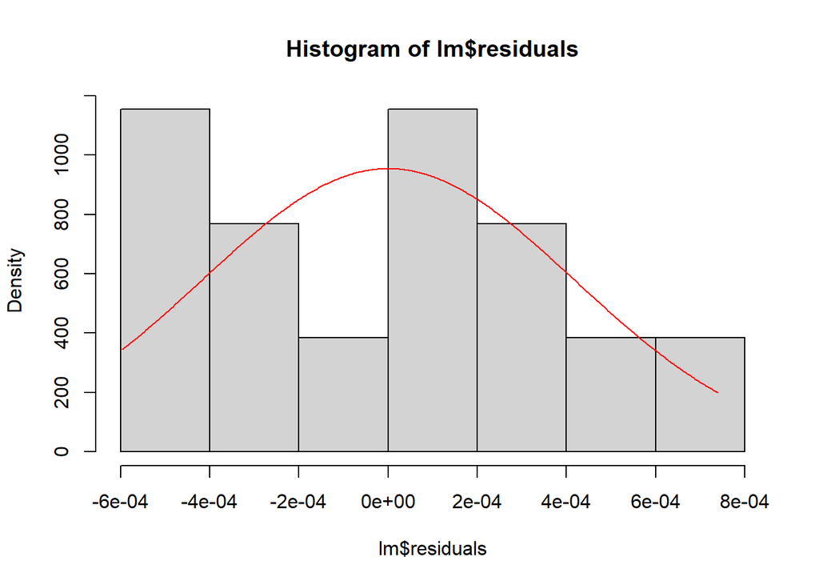

```r
hist(lm$residuals, 5, prob = T)
sigma <- summary(lm)$sigma

rg <- range(lm$residuals)
xg <- seq(rg[1], rg[2], len = 500)
yg <- dnorm(xg, mean = 0, sd = sigma)
lines(xg, yg, col = "red")
```

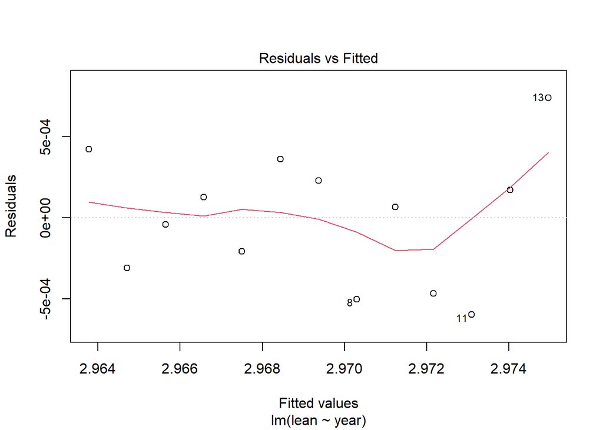

```r
plot(lm, which = 1)
```

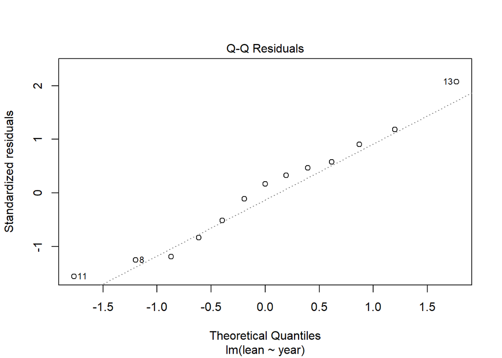

```r
plot(lm, which = 2)
```

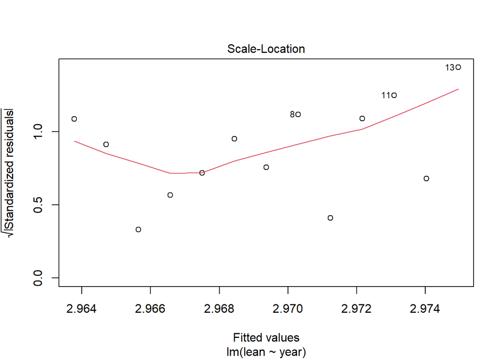

```r
plot(lm, which = 3)
```

**Answer:**

The residuals are not perfectly normal, which will affect statistical inferences (i.e. hypothesis tests, confidence intervals).

A. Linearity :

- *(Res VS Fitted Plot)* The residuals show a curved pattern rather than random scatter, which suggests non-linearity. This means the model may not fully capture the relationship between the predictors and the response variable.

B. Normality of Residuals:

- *(Histogram of Residuals)* The histogram shows deviations from a perfect bell shape, with some skewness.
- *(Q-Q Plot)* The Q-Q plot shows deviations in the tails; residuals do not align perfectly with the diagonal.

C. Constant Variance

- *(Scale-Location Plot)* The Scale-Location plot shows a fan-shaped pattern (residual spread increases as fitted values increase). Thus the residuals show non-constant variance.
9. Would it be a good idea to use the fitted linear regression equation to predict in year 2010? Explain your answer.

**Answer:**

No, it would not be a good idea. Based on the residual plots above, the model violates several assumptions **(i.e. Linearity, Normality of Residuals, Constance Variance)** that are critical for reliable predictions in linear regression.